# Summer Shooting – 2021

April 2, 2022

# Three Point Shooting 🏀

The three point shot has taken basketball, at every level, by storm over the last decade or so. It seems that the teams that are able to compete are the ones team cashing in on this valuable shot beyond the arc.

**Idaho State** ranked 9th out of 11 teams in the Big Sky conference for 3pt shooting percentage during the 2020-21 season at 33.3% on almost 21 attempts per game. Also, the **Bengals** ranked 8th out of 11 teams in 3 point field goals made per game.

Three point shooting is not the only thing that helps a team win, but it has become an important factor. The top 3 finishers in the Big Sky conference standings ranked 2nd, 3rd, and 4th, in 3pt FG makes per game in 2020-21 season. Now, I’m not suggesting their shooting prowess was *the* reason they had great success during conference play, but it is intriguing relationship.

# Summer Shooting

I was tasked with tracking and recording (and later visualizing and analyzing) tens of thousands of three point shots over the course of the summer. **ISU’s** players devoted dozens of hours in the gym with one goal: **get better at shooting the 3 ball**.

- **Spoiler Alert:** Although all players saw an [increase in performance](https://daisydaines.github.io/isu_mbb/summer_charts/) over the course of the summer, the team did not improve overall three point shooting during the subsequent 2021-22 season compared with the previous two seasons. 😞

# Season Comparison

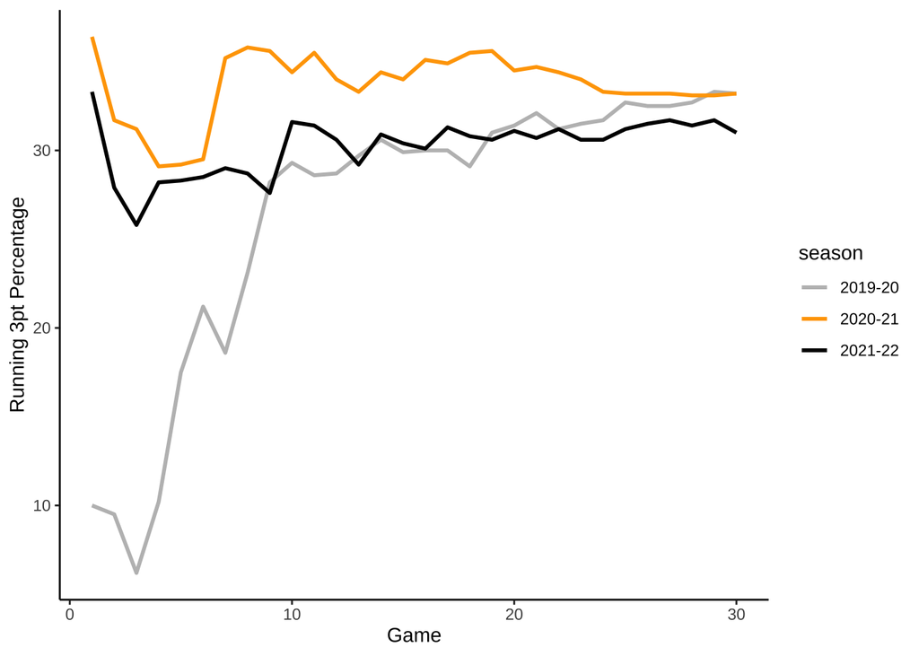

# Quick Thoughts

- The difference between 33% and 31% may seem trivial, but 2% on almost 700 3pt attempts during the season adds up quickly.
- Finishing above 33% for the 2021-22 season would have meant making 15+ more threes. That’s an extra three pointer every other game.
- **Idaho State** finished the season 7-23.
  - 10 of the 23 losses came by fewer than 9 points
  - 6 of those 10 single digit losses were by 5 points or fewer.
- An extra three here or there might have been the difference between a dismal 7-23 season or an ok 13-17 season 😔